# US Covid-19 Cases and Deaths(1/23/20-3/9/23)

Nicholas Anadon

2025-04-26

```r
library(tidyverse)
```

```r
library(dplyr)
library(tidyr)
library(lubridate)
library(ggplot2)
```

*Instructor Credit and Data Introduction:* Dr. Jane Wall was a sensational instructor for “Data Science as a Field” and per her permission on the final project, she has granted permission for the clean-up code of “COVID-19 Data Repository by the Center for Systems Science and Engineering (CSSE) at Johns Hopkins University” on Github.com. This project gives a cleaned version of COVID-19 cases and deaths strictly within the United States. The time period of these cases and deaths reported starts at January 23, 2020 to March 9, 2023. The goal is to analyze what months had more cases and deaths than others and what are the summary statistics behind the months with the most daily differences in COVID cases and deaths.

*Data set URL:* https://github.com/pomkos/john-hopkins-covid-data

```r
US_cases <- "https://raw.githubusercontent.com/CSSEGISandData/COVID-19/refs/heads/master/csse_covid_19_data/csse_covid_19_time_series/time_series_covid19_confirmed_US.csv"
US_deaths <- "https://raw.githubusercontent.com/CSSEGISandData/COVID-19/refs/heads/master/csse_covid_19_data/csse_covid_19_time_series/time_series_covid19_deaths_US.csv"

US_cases <- read.csv(US_cases)
US_deaths <- read.csv(US_deaths)
```

## Dr. Wall’s Cleanup Code and Summary of Code:

```r
#Values of US cases
US_cases <- US_cases %>%
  pivot_longer(cols = -(UID:Combined_Key),
               names_to = "date",
               values_to = "cases") %>%
  select(Admin2:cases) %>%
  select(-c(Lat, Long_))
US_cases$date <- as.Date(sub("^X", "", US_cases$date), format = "%m.%d.%y")


#Values of US deaths
US_deaths <- US_deaths %>%
  pivot_longer(cols = -(UID:Population),
               names_to = "date",
               values_to = "deaths") %>%
  select(Admin2:deaths) %>%
  select(-c(Lat, Long_))
US_deaths$date <- as.Date(sub("^X", "", US_deaths$date), format = "%m.%d.%y")

#Both US cases and US deaths have the same variables:
#Admin2 - City within the State
#Province_State - US State
#Country_Region - Always US(Important to note that this data set only has US
#data while global statistics were also recorded)
#Combined_Key - City + State
#Population - Total population recorded at the start date
#date - Date


#full_join() combines the variables not included in both data sets.

#cases - Cumulative sum of cases within a state as time progresses
#deaths - Cumulative sum of deaths within a state as time progresses
US <- US_cases %>%
  full_join(US_deaths)
```

[output not shown]

```r
#Eliminating negative values
US <- US %>%
  mutate(
    cases = pmax(cases, 0),
    deaths = pmax(deaths, 0)
  )

tail(US)
```

```
## # A tibble: 6 × 8
##   Admin2 Province_State Country_Region Combined_Key  date       cases Population
##   <chr>  <chr>          <chr>          <chr>         <date>     <dbl>      <int>
## 1 Weston Wyoming        US             Weston, Wyom… 2023-03-04  1905       6927
## 2 Weston Wyoming        US             Weston, Wyom… 2023-03-05  1905       6927
## 3 Weston Wyoming        US             Weston, Wyom… 2023-03-06  1905       6927
## 4 Weston Wyoming        US             Weston, Wyom… 2023-03-07  1905       6927
## 5 Weston Wyoming        US             Weston, Wyom… 2023-03-08  1905       6927
## 6 Weston Wyoming        US             Weston, Wyom… 2023-03-09  1905       6927
## # ℹ 1 more variable: deaths <dbl>
```

```r
summary(US)
```

```
##     Admin2          Province_State     Country_Region     Combined_Key
##  Length:3819906     Length:3819906     Length:3819906     Length:3819906
##  Class :character   Class :character   Class :character   Class :character
##  Mode  :character   Mode  :character   Mode  :character   Mode  :character
##
##
##
##       date                cases           Population           deaths
##  Min.   :2020-01-22   Min.   :      0   Min.   :       0   Min.   :    0.0
##  1st Qu.:2020-11-02   1st Qu.:    330   1st Qu.:    9917   1st Qu.:    4.0
##  Median :2021-08-15   Median :   2272   Median :   24892   Median :   37.0
##  Mean   :2021-08-15   Mean   :  14088   Mean   :   99604   Mean   :  186.9
##  3rd Qu.:2022-05-28   3rd Qu.:   8159   3rd Qu.:   64979   3rd Qu.:  122.0
##  Max.   :2023-03-09   Max.   :3710586   Max.   :10039107   Max.   :35545.0
```

```r
#Combining data from all cities within states
US_by_state <- US %>%
  group_by(Province_State, Country_Region, date) %>%
  summarize(cases = sum(cases), deaths = sum(deaths),
            Population = sum(Population)) %>%
  mutate(deaths_per_mill = deaths * 1000000 / Population) %>%
  select(Province_State, Country_Region, date,
         cases, deaths, deaths_per_mill, Population) %>%
  ungroup()
tail(US_by_state)
```

```
## # A tibble: 6 × 7
##   Province_State Country_Region date        cases deaths deaths_per_mill
##   <chr>          <chr>          <date>      <dbl>  <dbl>           <dbl>
## 1 Wyoming        US             2023-03-04 185159   2002           3459.
## 2 Wyoming        US             2023-03-05 185159   2002           3459.
## 3 Wyoming        US             2023-03-06 185159   2002           3459.
## 4 Wyoming        US             2023-03-07 185385   2004           3463.
## 5 Wyoming        US             2023-03-08 185385   2004           3463.
## 6 Wyoming        US             2023-03-09 185385   2004           3463.
## # ℹ 1 more variable: Population <int>
```

```r
#Combining data from states within the United States
US_totals <- US_by_state %>%
  group_by(Country_Region, date) %>%
  summarize(cases = sum(cases), deaths = sum(deaths),
            Population = sum(Population)) %>%
  mutate(deaths_per_mill = deaths * 1000000 / Population) %>%
  select(Country_Region, date,
         cases, deaths, deaths_per_mill, Population) %>%
  ungroup()
#deaths_per_mill - Number of deaths expected out of 1 million people in relation to the population
tail(US_totals)
```

```
## # A tibble: 6 × 6
##   Country_Region date           cases  deaths deaths_per_mill Population
##   <chr>          <date>         <dbl>   <dbl>           <dbl>      <int>
## 1 US             2023-03-04 103650837 1122172           3371.  332875137
## 2 US             2023-03-05 103646975 1122134           3371.  332875137
## 3 US             2023-03-06 103655539 1122181           3371.  332875137
## 4 US             2023-03-07 103690910 1122516           3372.  332875137
## 5 US             2023-03-08 103755771 1123246           3374.  332875137
## 6 US             2023-03-09 103802702 1123836           3376.  332875137
```

```r
summary(US_totals)
```

```
##  Country_Region          date                cases               deaths
##  Length:1143        Min.   :2020-01-22   Min.   :        1   Min.   :      1
##  Class :character   1st Qu.:2020-11-02   1st Qu.:  9401880   1st Qu.: 232564
##  Mode  :character   Median :2021-08-15   Median : 36845902   Median : 618029
##                     Mean   :2021-08-15   Mean   : 47080800   Mean   : 624563
##                     3rd Qu.:2022-05-27   3rd Qu.: 84083678   3rd Qu.:1006626
##                     Max.   :2023-03-09   Max.   :103802702   Max.   :1123836
##  deaths_per_mill      Population
##  Min.   :   0.003   Min.   :332875137
##  1st Qu.: 698.652   1st Qu.:332875137
##  Median :1856.639   Median :332875137
##  Mean   :1876.268   Mean   :332875137
##  3rd Qu.:3024.033   3rd Qu.:332875137
##  Max.   :3376.149   Max.   :332875137
```

```r
US_totals <- US_totals %>%
  mutate(new_cases = cases - lag(cases),
         new_deaths = deaths - lag(deaths))
#It's important to note that some values in new_cases and new_deaths are
#negative. This is okay, because we are looking at the difference between cases
#of one day and the day prior regardless if someone already had the disease or
#had just caught the disease that day. Thinking in real time, if there were
#fewer cases today than yesterday, the result would be negative.
```

## Nicholas Anadon’s Data Fixes and Summaries:

```r
#Only one data value contained an NA value so it has been omitted

#Months and Seasons are primary variables of interest

#For simplicity in the next few data visualizations the seasons cut off after
#the month in which the next season begins
US_totals <- na.omit(US_totals)
US_totals$month <- month(US_totals$date, label = TRUE)
US_totals$month_name <- month(US_totals$date, label = TRUE, abbr = TRUE)

US_totals$Season <- case_when(
  US_totals$month %in% c("Jan", "Feb", "Mar") ~ "Winter",
  US_totals$month %in% c("Apr", "May", "Jun") ~ "Spring",
  US_totals$month %in% c("Jul", "Aug", "Sep") ~ "Summer",
  US_totals$month %in% c("Oct", "Nov", "Dec") ~ "Fall"
)

US_totals$Year <- year(US_totals$date)

tail(US_totals)
```

```
## # A tibble: 6 × 12
##   Country_Region date          cases deaths deaths_per_mill Population new_cases
##   <chr>          <date>        <dbl>  <dbl>           <dbl>      <int>     <dbl>
## 1 US             2023-03-04   1.04e8 1.12e6           3371.  332875137      2147
## 2 US             2023-03-05   1.04e8 1.12e6           3371.  332875137     -3862
## 3 US             2023-03-06   1.04e8 1.12e6           3371.  332875137      8564
## 4 US             2023-03-07   1.04e8 1.12e6           3372.  332875137     35371
## 5 US             2023-03-08   1.04e8 1.12e6           3374.  332875137     64861
## 6 US             2023-03-09   1.04e8 1.12e6           3376.  332875137     46931
## # ℹ 5 more variables: new_deaths <dbl>, month <ord>, month_name <ord>,
## #   Season <chr>, Year <dbl>
```

*Timeframe of Covid-19 Cases and Deaths:* The time frame graphs do not give a cumulative sum, but instead read the difference of new cases and deaths on one particular day compared to the day before. The drops in the graph represent zero or small negative change. Note the difference in scale between cases and deaths on the y-axis of the graphs where difference in cases reach over 1,000,000 on one day compared to deaths where the maximum amount of difference of deaths between two days was over 4000. The red line in the “New Deaths in US by Month” graph illustrates a slow growth of deaths per million of people.

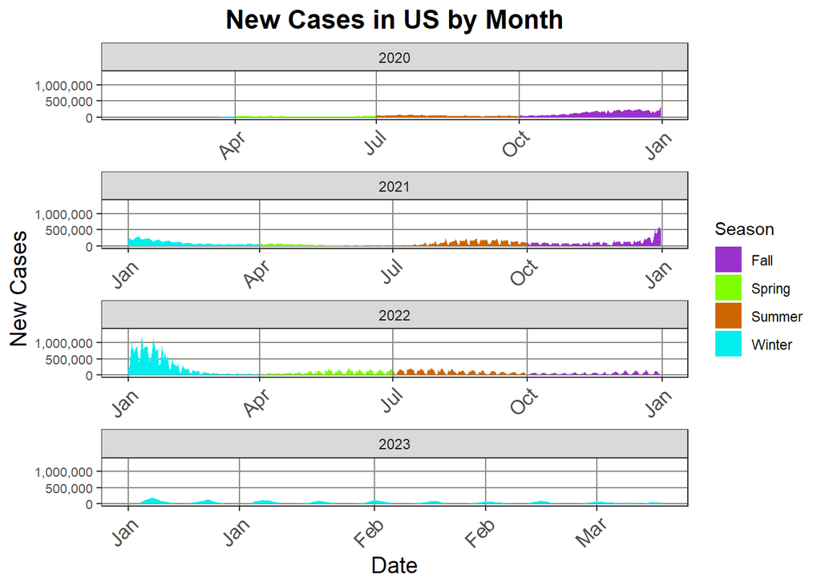

```r
US_totals %>% ggplot() +
  geom_area(aes(x = date, y = new_cases, fill = Season)) +
  facet_wrap(~ Year, ncol = 1, scales = "free_x") +
  scale_x_date(date_labels = "%b") +
  scale_fill_manual(values = c(
    "Winter" = "#00EEEE",
    "Spring" = "#7FFF00",
    "Summer" = "#CD6600",
    "Fall" = "#9932CC"
  )) +
  scale_y_continuous(labels = scales::comma) +
  labs(title = "New Cases in US by Month",
       x = "Date",
       y = "New Cases") +
  theme_bw() +
  theme(
    axis.text.x = element_text(angle = 45, hjust = 1),
    axis.text.y = element_text(size = 8),
    plot.title = element_text(hjust = 0.5, face = "bold", size = 16),
    axis.title = element_text(size = 14),
    axis.text = element_text(size = 12),
    panel.grid.major = element_line(color = "#8B8B83"),
    panel.grid.minor = element_blank()
    )
```

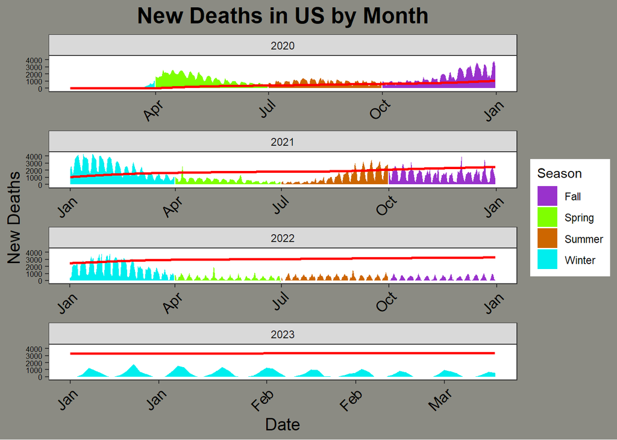

```r
US_totals %>% ggplot() +
  geom_area(aes(x = date, y = new_deaths, fill = Season)) +
  geom_line(aes(x = date, y = deaths_per_mill), color = "red", linewidth = 1) +
  facet_wrap(~ Year, ncol = 1, scales = "free_x") +
  scale_x_date(date_labels = "%b") +
  scale_fill_manual(values = c(
    "Winter" = "#00EEEE",
    "Spring" = "#7FFF00",
    "Summer" = "#CD6600",
    "Fall" = "#9932CC"
  )) +
  labs(title = "New Deaths in US by Month",
       x = "Date",
       y = "New Deaths") +
  theme_bw() +
  theme(axis.text.x = element_text(angle = 45, hjust = 1),
        axis.text.y = element_text(size = 6),
        plot.title = element_text(hjust = 0.5, face = "bold", size = 18),
        axis.title = element_text(size = 14, color = "#000000"),
        axis.text = element_text(size = 12, color = "#000000"),
        panel.grid = element_blank(),
        plot.background = element_rect(fill = "#8B8B83", color = NA)
        )
```

## Quantitative Boxplot Analysis:

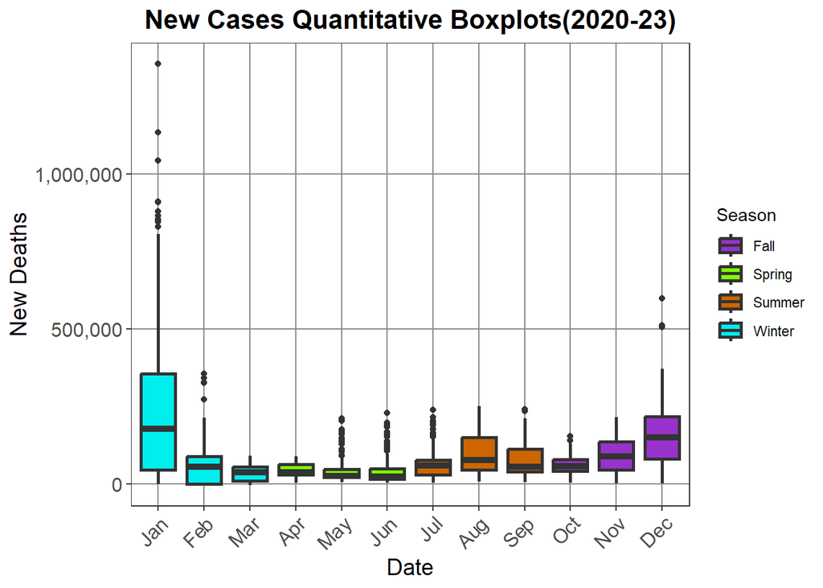

```r
US_totals %>% ggplot() +
  geom_boxplot(aes(x = month, y = new_cases, fill = Season), linewidth = 0.9) +
  scale_fill_manual(values = c(
    "Winter" = "#00EEEE",
    "Spring" = "#7FFF00",
    "Summer" = "#CD6600",
    "Fall" = "#9932CC"
  )) +
  scale_y_continuous(labels = scales::comma) +
  labs(title = "New Cases Quantitative Boxplots(2020-23)",
       x = "Date",
       y = "New Deaths") +
  theme_bw() +
  theme(
    axis.text.x = element_text(angle = 45, hjust = 1),
    plot.title = element_text(hjust = 0.5, face = "bold", size = 16),
    axis.title = element_text(size = 14),
    axis.text = element_text(size = 12),
    panel.grid.major = element_line(color = "#8B8B83"),
    panel.grid.minor = element_blank()
  )
```

```r
summary(US_totals$new_cases)
```

```
##    Min. 1st Qu.  Median    Mean 3rd Qu.    Max.
##   -3862   25993   55971   90896  112464 1354508
```

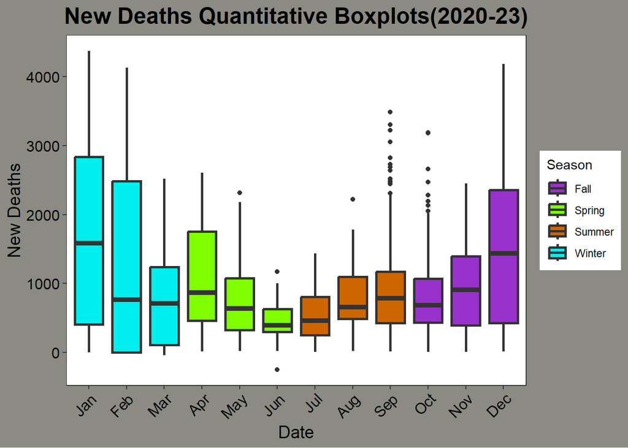

```r
US_totals %>% ggplot() +
  geom_boxplot(aes(x = month, y = new_deaths, fill = Season), linewidth = 0.9) +
  scale_fill_manual(values = c(
    "Winter" = "#00EEEE",
    "Spring" = "#7FFF00",
    "Summer" = "#CD6600",
    "Fall" = "#9932CC"
  )) +
  labs(title = "New Deaths Quantitative Boxplots(2020-23)",
       x = "Date",
       y = "New Deaths") +
  theme_bw() +
  theme(axis.text.x = element_text(angle = 45, hjust = 1),
        plot.title = element_text(hjust = 0.5, face = "bold", size = 18),
        axis.title = element_text(size = 14, color = "#000000"),
        axis.text = element_text(size = 12, color = "#000000"),
        panel.grid = element_blank(),
        plot.background = element_rect(fill = "#8B8B83", color = NA)
  )
```

```r
summary(US_totals$new_deaths)
```

```
##    Min. 1st Qu.  Median    Mean 3rd Qu.    Max.
##  -253.0   324.0   706.5   984.1  1415.0  4375.0
```

*New Cases and New Deaths Analysis:*

### New Cases

The day that had the greatest difference in new cases was +1,354,508 more cases on January 10, 2022 than January 9, 2022. Late fall 2021 - early winter 2022 was a time of extreme COVID-19 spread. On average, the difference in new cases was about +90,896. This average is heavily influenced by outliers of days with huge amounts of case differences especially during December, 2021 and Janurary, 2022. Even when the vaccine was distributed in mid-2021, cases started to explode toward the end of 2021 as people in America were trying to return to their standard way of life.

### New Deaths

According to the new deaths boxplots, we can estimate the future death difference between two days is +985 deaths. This number does not make sense at the beginning of the pandemic, but as the virus continued to spread, the amount of deaths would steadily increase. The day with the greatest difference in deaths was January 12, 2021 with +4375 more people that died from COVID-19 compared to January 11, 2021. January, Feburary, and December have the greatest variability of daily death differences as the colder weather can lead to lower sunlight and weakened immune systems. There are many outliers in September and October due to a pattern similar to Influenza where as the weather starts to get colder and darker, cases and deaths steadily go up leading into winters.

*Linear Model:* If there is no difference in new cases presented on a day from the day before, we could estimate a death toll difference of about +648-649 people to die that same day. According to the linear estimates, for every difference of +270 new cases adds +1 difference of deaths. The adjusted R-squared value of 0.2531 indicates a weak, positive correlation between the daily difference of cases and daily difference of deaths, but not enough to indicate a very strong correlation. This certainly would explain the extreme spread of the data especially during seasonal changes.

```r
mod2 <- lm(new_deaths ~ new_cases, data = US_totals)
mod2
```

```
##
## Call:
## lm(formula = new_deaths ~ new_cases, data = US_totals)
##
## Coefficients:
## (Intercept)    new_cases
##   6.486e+02    3.691e-03
```

```r
summary(mod2)
```

```
##
## Call:
## lm(formula = new_deaths ~ new_cases, data = US_totals)
##
## Residuals:
##     Min      1Q  Median      3Q     Max
## -3600.4  -580.7  -235.7   320.3  3032.7
##
## Coefficients:
##              Estimate Std. Error t value Pr(>|t|)
## (Intercept) 6.486e+02  2.920e+01   22.21   <2e-16 ***
## new_cases   3.691e-03  1.875e-04   19.69   <2e-16 ***
## ---
## Signif. codes:  0 '***' 0.001 '**' 0.01 '*' 0.05 '.' 0.1 ' ' 1
##
## Residual standard error: 801.5 on 1140 degrees of freedom
## Multiple R-squared:  0.2538, Adjusted R-squared:  0.2531
## F-statistic: 387.7 on 1 and 1140 DF,  p-value: < 2.2e-16
```

*Project Bias:* There are many instances of bias that we need to account for:

-Different states have different COVID protocols. We can not assume that the method of measurements were the same throughout all states. Healthcare is different across all states as well.

-This dataset presents a huge emphasis on urban trends and areas. While rural areas are included, it is easy for these areas to be underrepresented.

-Considering that symptoms for some individuals registered as asymptomatic or mild, it would be wrong to assume that there were no more cases outside of those reported in this study.

*Project Conclusion:* January was the month with the greatest daily differences in COVID cases and the cold months of January, February, and December produce enormous variability of daily death differences compared to warmer months. While the relationship in differences between COVID-19 cases and deaths was not correlated to a powerful extent, the seasonal patterns align with extreme outliers as averages increase with colder weather. While a difference in +200-300 cases does not necessarily predict how many people will die, it is still an important statistic for public health information to take into consideration when examining other lurking variables. While we certainly should not leave out the warmer months from early spring to earlier fall, we can safely say that winter/colder months, especially January 2021 and January 2022, had the greatest COVID-19 outbreaks. In the future, if more pandemics are to occur, we can at least try to focus our efforts toward stronger healthcare in colder months and give individuals incentives that allow them to practice habits and activities to enhance their overall health.